# Supervised Learning - Foundations Project: ReCell

## Data Preprocessing

- Missing value treatment
- Feature engineering (if needed)
- Outlier detection and treatment (if needed)
- Preparing data for modeling
- Any other preprocessing steps (if needed)

**Missing Values Treatment**

```python
#We make a copy of the data
dfproc=pdcell.copy()
```

**Check missing values**

```python
dfproc.isnull().sum()
```

```
brand_name                 0
os                         0
screen_size                0
4g                         0
5g                         0
main_camera_mp           179
selfie_camera_mp           2
int_memory                 4
ram                        4
battery                    6
weight                     7
release_year               0
days_used                  0
normalized_used_price      0
normalized_new_price       0
dtype: int64
```

main_camera_mp, selfie_camera_mp, int_memory, ram, battery, and weight have missing values

```python
#we impute the missing values with the median
cols_impute = [
    "main_camera_mp",
    "selfie_camera_mp",
    "int_memory",
    "ram",
    "battery",
    "weight",
]
#impute missing values in cols_impute with median by grouping the data on release year and brand name
for col in cols_impute:
    dfproc[col] = dfproc[col].fillna(
        value=dfproc.groupby(['release_year','brand_name'])[col].transform("median"))
```

```python
dfproc.isnull().sum()
```

```
brand_name                 0
os                         0
screen_size                0
4g                         0
5g                         0
main_camera_mp           179
selfie_camera_mp           2
int_memory                 0
ram                        0
battery                    6
weight                     7
release_year               0
days_used                  0
normalized_used_price      0
normalized_new_price       0
dtype: int64
```

We impute the remaining missing values in the data by the column medians grouped by brand_name.

```python
cols_impute = [
    "main_camera_mp",
    "selfie_camera_mp",
    "battery",
    "weight",
]
 ## We impute the remaining missing values in cols_impute with median by grouping the data on brand name
for col in cols_impute:
    dfproc[col] = dfproc[col].fillna(
        value=dfproc.groupby(['brand_name'])[col].transform("median")
    )
```

```python
#We check missing values
dfproc.isnull().sum()
```

```
brand_name                0
os                        0
screen_size               0
4g                        0
5g                        0
main_camera_mp           10
selfie_camera_mp          0
int_memory                0
ram                       0
battery                   0
weight                    0
release_year              0
days_used                 0
normalized_used_price     0
normalized_new_price      0
dtype: int64
```

1. Main Camera MP still has missing values
2. We will fill the remaining missing values in the main_camera_mp column by the column median.

```python
dfproc["main_camera_mp"] = dfproc["main_camera_mp"].fillna(dfproc["main_camera_mp"].median)
```

```python
#We check missing values after imputing everything
dfproc.isnull().sum()
```

```
brand_name               0
os                       0
screen_size              0
4g                       0
5g                       0
main_camera_mp           0
selfie_camera_mp         0
int_memory               0
ram                      0
battery                  0
weight                   0
release_year             0
days_used                0
normalized_used_price    0
normalized_new_price     0
dtype: int64
```

```python
dfproc.info()
```

```
<class 'pandas.core.frame.DataFrame'>
RangeIndex: 3454 entries, 0 to 3453
Data columns (total 15 columns):
 #   Column                 Non-Null Count  Dtype
---  ------                 --------------  -----
 0   brand_name             3454 non-null   object
 1   os                     3454 non-null   object
 2   screen_size            3454 non-null   float64
 3   4g                     3454 non-null   object
 4   5g                     3454 non-null   object
 5   main_camera_mp         3454 non-null   object
 6   selfie_camera_mp       3454 non-null   float64
 7   int_memory             3454 non-null   float64
 8   ram                    3454 non-null   float64
 9   battery                3454 non-null   float64
 10  weight                 3454 non-null   float64
 11  release_year           3454 non-null   int64
 12  days_used              3454 non-null   int64
 13  normalized_used_price  3454 non-null   float64
 14  normalized_new_price   3454 non-null   float64
dtypes: float64(8), int64(2), object(5)
memory usage: 404.9+ KB
```

```python
#convert main_camera_mp to float
dfproc['main_camera_mp'] = pd.to_numeric(dfproc['main_camera_mp'],errors = 'coerce')
```

```python
dfproc.info()
```

```
<class 'pandas.core.frame.DataFrame'>
RangeIndex: 3454 entries, 0 to 3453
Data columns (total 15 columns):
 #   Column                 Non-Null Count  Dtype
---  ------                 --------------  -----
 0   brand_name             3454 non-null   object
 1   os                     3454 non-null   object
 2   screen_size            3454 non-null   float64
 3   4g                     3454 non-null   object
 4   5g                     3454 non-null   object
 5   main_camera_mp         3444 non-null   float64
 6   selfie_camera_mp       3454 non-null   float64
 7   int_memory             3454 non-null   float64
 8   ram                    3454 non-null   float64
 9   battery                3454 non-null   float64
 10  weight                 3454 non-null   float64
 11  release_year           3454 non-null   int64
 12  days_used              3454 non-null   int64
 13  normalized_used_price  3454 non-null   float64
 14  normalized_new_price   3454 non-null   float64
dtypes: float64(9), int64(2), object(4)
memory usage: 404.9+ KB
```

```python
dfproc.head()
```

|  | brand_name | os | screen_size | 4g | 5g | main_camera_mp | selfie_camera_mp | int_memory | ram | battery | weight | release_year | days_used | normalized_used_price | normalized_new_price |
| --- | --- | --- | --- | --- | --- | --- | --- | --- | --- | --- | --- | --- | --- | --- | --- |
| 0 | Honor | Android | 14.50 | yes | no | 13.0 | 5.0 | 64.0 | 3.0 | 3020.0 | 146.0 | 2020 | 127 | 4.307572 | 4.715100 |
| 1 | Honor | Android | 17.30 | yes | yes | 13.0 | 16.0 | 128.0 | 8.0 | 4300.0 | 213.0 | 2020 | 325 | 5.162097 | 5.519018 |
| 2 | Honor | Android | 16.69 | yes | yes | 13.0 | 8.0 | 128.0 | 8.0 | 4200.0 | 213.0 | 2020 | 162 | 5.111084 | 5.884631 |
| 3 | Honor | Android | 25.50 | yes | yes | 13.0 | 8.0 | 64.0 | 6.0 | 7250.0 | 480.0 | 2020 | 345 | 5.135387 | 5.630961 |
| 4 | Honor | Android | 15.32 | yes | no | 13.0 | 8.0 | 64.0 | 3.0 | 5000.0 | 185.0 | 2020 | 293 | 4.389995 | 4.947837 |

Feature Engineering We create a new column years_since_release from the release_year column. We consider the year of data collection, 2021, as the baseline. We will drop the release_year column after computing the new column of years_since_release.

```python
dfproc["years_since_release"] = 2021 - dfproc["release_year"]
dfproc.drop("release_year", axis=1, inplace=True)
```

```python
dfproc["years_since_release"].describe()
```

```
count    3454.000000
mean        5.034742
std         2.298455
min         1.000000
25%         3.000000
50%         5.500000
75%         7.000000
max         8.000000
Name: years_since_release, dtype: float64
```

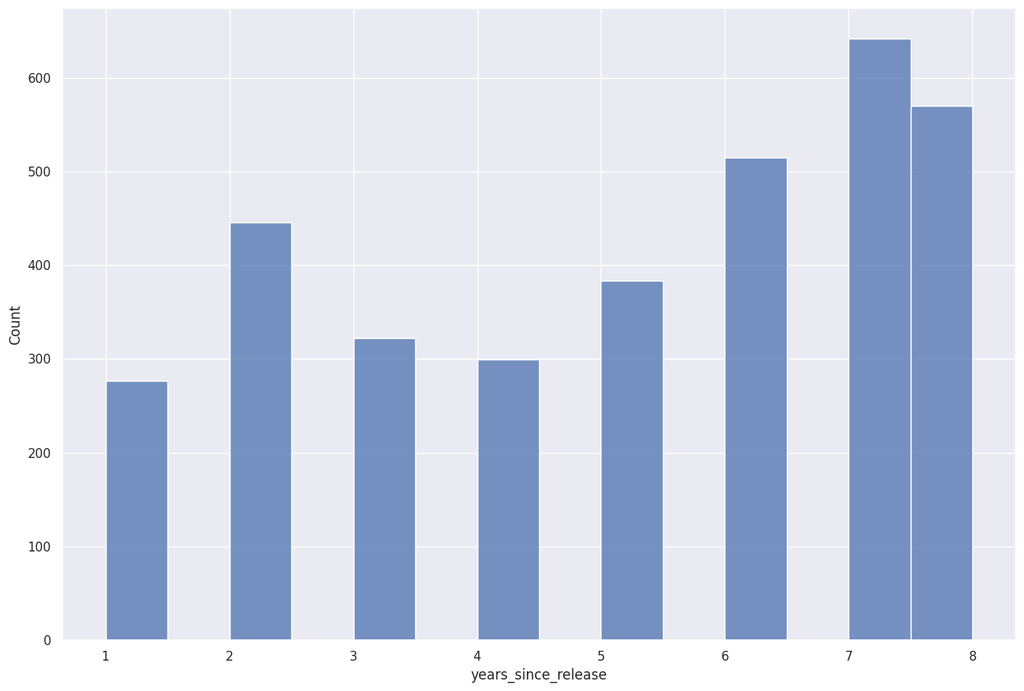

```python
plt.figure(figsize=(15, 10))
sns.histplot(data=dfproc, x="years_since_release")
plt.show()
```

1. Phones that have lasted the most have lasted for 7 years followed by those that have lasted for 8 years.
2. The minimum period a phone has lasted is 1 year.

We Conduct Outlier checks

[figure not shown]

```python
numeric_columns = dfproc.select_dtypes(include=np.number).columns.tolist()

plt.figure(figsize=(15, 15))

for i, variable in enumerate(numeric_columns):
    plt.subplot(3, 4, i + 1)
    plt.boxplot(dfproc[variable], whis=1.5)
    plt.tight_layout()
    plt.title(variable)

plt.show()
```

Analysis of Outliers for the normalized_new_price

```python
import plotly.express as px
```

```python
#create a histogram

fig = px.histogram(dfproc, x="normalized_new_price")

fig.show()
```

[interactive chart not shown]

```python
#create a histogram

fig = px.box(dfproc, x="normalized_new_price")

fig.show()
```

[interactive chart not shown]

```python
#create a function to find outliers using IQR

def find_outliers_IQR(df):

   q1=df.quantile(0.25)

   q3=df.quantile(0.75)

   IQR=q3-q1

   outliers = df[((df<(q1-1.5*IQR)) | (df>(q3+1.5*IQR)))]

   return outliers
```

```python
outliers = find_outliers_IQR(df=dfproc["normalized_new_price"])

print("number of outliers: " + str(len(outliers)))

print("max outlier value: " + str(outliers.max()))

print("min outlier value: " + str(outliers.min()))

outliers
```

```
number of outliers: 66
max outlier value: 7.847840659422009
min outlier value: 2.9014215940827497
```

```
34      7.244220
44      7.438007
84      7.003175
109     7.090785
113     3.399863
          ...
2893    3.427839
3207    7.847841
3348    7.847841
3436    7.333016
3448    7.059317
Name: normalized_new_price, Length: 66, dtype: float64
```

```python
df_new_prc_outliers = dfproc[dfproc["normalized_new_price"].isin(outliers)]
df_new_prc_outliers.shape
```

```
(66, 15)
```

```python
df_new_prc_outliers.head(20)
```

|  | brand_name | os | screen_size | 4g | 5g | main_camera_mp | selfie_camera_mp | int_memory | ram | battery | weight | days_used | normalized_used_price | normalized_new_price | years_since_release |
| --- | --- | --- | --- | --- | --- | --- | --- | --- | --- | --- | --- | --- | --- | --- | --- |
| 34 | Huawei | Android | 16.71 | yes | yes | 10.5 | 16.0 | 256.00 | 8.00 | 4200.0 | 226.0 | 120 | 6.153456 | 7.244220 | 1 |
| 44 | Huawei | Android | 16.59 | yes | yes | 13.0 | 16.0 | 512.00 | 12.00 | 4500.0 | 198.0 | 289 | 5.674182 | 7.438007 | 2 |
| 84 | LG | Android | 15.34 | yes | yes | 8.0 | 32.0 | 256.00 | 8.00 | 4000.0 | 192.0 | 383 | 5.467680 | 7.003175 | 2 |
| 109 | Motorola | Android | 15.42 | yes | yes | 13.0 | 25.0 | 256.00 | 12.00 | 5000.0 | 203.0 | 220 | 5.186883 | 7.090785 | 1 |
| 113 | Nokia | Others | 5.18 | no | no | 0.3 | 0.0 | 0.10 | 0.03 | 1020.0 | 90.5 | 272 | 2.910174 | 3.399863 | 1 |
| 114 | Nokia | Others | 5.18 | no | no | 0.3 | 0.0 | 0.06 | 2.00 | 1020.0 | 91.3 | 288 | 2.729159 | 2.911263 | 1 |
| 198 | Xiaomi | Android | 20.12 | yes | yes | 12.0 | 20.0 | 512.00 | 12.00 | 4050.0 | 241.0 | 478 | 6.619433 | 7.823342 | 2 |
| 253 | Huawei | Android | 16.71 | yes | yes | 10.5 | 16.0 | 256.00 | 8.00 | 4200.0 | 226.0 | 215 | 5.493802 | 7.243134 | 1 |
| 263 | Huawei | Android | 16.59 | yes | yes | 13.0 | 16.0 | 512.00 | 12.00 | 4500.0 | 198.0 | 488 | 5.995954 | 7.439289 | 2 |
| 303 | LG | Android | 15.34 | yes | yes | 8.0 | 32.0 | 256.00 | 8.00 | 4000.0 | 192.0 | 471 | 5.789104 | 7.003347 | 2 |
| 328 | Motorola | Android | 15.42 | yes | yes | 13.0 | 25.0 | 256.00 | 12.00 | 5000.0 | 203.0 | 188 | 5.639813 | 7.087983 | 1 |
| 332 | Nokia | Others | 5.18 | no | no | 0.3 | 0.0 | 0.06 | 0.03 | 1020.0 | 90.5 | 322 | 2.519308 | 3.386422 | 1 |
| 333 | Nokia | Others | 5.18 | no | no | 0.3 | 0.0 | 0.10 | 0.03 | 1020.0 | 91.3 | 148 | 2.564949 | 3.011606 | 1 |
| 372 | Samsung | Android | 15.32 | yes | yes | 12.0 | 10.0 | 256.00 | 12.00 | 3500.0 | 168.0 | 190 | 4.997685 | 7.003629 | 2 |
| 520 | Alcatel | Others | 7.75 | no | no | 1.3 | 0.3 | 256.00 | 0.25 | 1000.0 | 93.0 | 672 | 2.506342 | 3.323956 | 7 |
| 533 | Alcatel | Others | 5.18 | no | no | 0.3 | 0.3 | 16.00 | 0.25 | 850.0 | 77.9 | 809 | 1.617406 | 3.371769 | 7 |
| 534 | Alcatel | Others | 5.18 | no | no | 2.0 | 0.3 | 128.00 | 4.00 | 850.0 | 85.0 | 656 | 2.335052 | 3.014063 | 7 |
| 618 | Others | Others | 5.18 | no | no | 0.08 | 2.0 | 16.00 | 4.00 | 1000.0 | 80.0 | 1008 | 2.630449 | 2.942331 | 7 |
| 630 | Others | Others | 5.28 | no | no | 2.0 | 0.3 | 16.00 | 4.00 | 1280.0 | 113.6 | 1046 | 2.915606 | 3.047850 | 8 |
| 644 | Apple | iOS | 30.71 | yes | no | 12.0 | 7.0 | 1024.00 | 4.00 | 9720.0 | 631.0 | 543 | 5.808022 | 7.003847 | 3 |

Analysis of Outliers for the weight

```python
dfproc.weight.describe().T
```

```
count    3454.000000
mean      182.636856
std        88.360445
min        69.000000
25%       142.000000
50%       160.000000
75%       185.000000
max       855.000000
Name: weight, dtype: float64
```

```python
#create a histogram

fig = px.histogram(dfproc, x="normalized_new_price")

fig.show()
```

[interactive chart not shown]

```python
#create a boxplot

fig = px.box(dfproc, x="weight")

fig.show()
```

[interactive chart not shown]

See the many Outliers on the right of the upper fence

```python
#Use the outliers function defined above to isolate the outliers
outliers = find_outliers_IQR(df=dfproc["weight"])

print("number of outliers: " + str(len(outliers)))

print("max outlier value: " + str(outliers.max()))

print("min outlier value: " + str(outliers.min()))

outliers
```

```
number of outliers: 368
max outlier value: 855.0
min outlier value: 69.0
```

```
3       480.0
21      453.6
31      310.0
33      450.0
36      460.0
        ...
3278    290.0
3279    290.0
3304    253.0
3348    300.0
3436    263.0
Name: weight, Length: 368, dtype: float64
```

There are 368 outliers Themaximum outlier is 855 and the minimum is 69

```python
#Create a dataframe with the outliers
df_weight_outliers = dfproc[dfproc["weight"].isin(outliers)]
df_weight_outliers.shape
```

```
(368, 15)
```

```python
#View the outliers data
df_weight_outliers.head(20)
```

|  | brand_name | os | screen_size | 4g | 5g | main_camera_mp | selfie_camera_mp | int_memory | ram | battery | weight | days_used | normalized_used_price | normalized_new_price | years_since_release |
| --- | --- | --- | --- | --- | --- | --- | --- | --- | --- | --- | --- | --- | --- | --- | --- |
| 3 | Honor | Android | 25.50 | yes | yes | 13.0 | 8.0 | 64.0 | 6.0 | 7250.0 | 480.0 | 345 | 5.135387 | 5.630961 | 1 |
| 21 | Others | Android | 20.32 | no | no | 8.0 | 0.3 | 16.0 | 1.0 | 5680.0 | 453.6 | 933 | 4.452136 | 5.484382 | 8 |
| 31 | Huawei | Android | 20.32 | yes | no | 5.0 | 2.0 | 16.0 | 2.0 | 5100.0 | 310.0 | 231 | 4.170534 | 4.598246 | 1 |
| 33 | Huawei | Android | 25.50 | yes | no | 8.0 | 8.0 | 64.0 | 4.0 | 7250.0 | 450.0 | 211 | 5.133089 | 5.518777 | 1 |
| 36 | Huawei | Android | 25.60 | yes | yes | 13.0 | 8.0 | 128.0 | 6.0 | 7250.0 | 460.0 | 139 | 5.182457 | 6.310336 | 1 |
| 40 | Huawei | Android | 25.60 | yes | no | 13.0 | 8.0 | 128.0 | 6.0 | 7250.0 | 460.0 | 256 | 4.997685 | 6.107268 | 2 |
| 49 | Huawei | Android | 25.60 | yes | no | 13.0 | 8.0 | 64.0 | 4.0 | 7500.0 | 498.0 | 205 | 4.936630 | 5.704782 | 2 |
| 50 | Huawei | Android | 20.42 | yes | no | 13.0 | 8.0 | 128.0 | 6.0 | 6100.0 | 340.0 | 406 | 5.294259 | 5.856933 | 2 |
| 51 | Huawei | Android | 20.42 | yes | no | 13.0 | 8.0 | 64.0 | 4.0 | 6100.0 | 320.0 | 462 | 5.001191 | 5.556287 | 2 |
| 58 | Huawei | Android | 17.78 | no | no | 3.15 | 0.3 | 8.0 | 1.0 | 4100.0 | 350.0 | 819 | 3.982295 | 5.016551 | 8 |
| 66 | Lenovo | Android | 25.43 | yes | no | 8.0 | 5.0 | 32.0 | 3.0 | 7000.0 | 520.0 | 233 | 4.726768 | 5.201366 | 1 |
| 67 | Lenovo | Android | 25.43 | no | no | 8.0 | 5.0 | 64.0 | 4.0 | 7000.0 | 580.0 | 419 | 5.214881 | 5.775141 | 2 |
| 69 | Lenovo | Android | 20.32 | yes | no | 13.0 | 5.0 | 16.0 | 2.0 | 5100.0 | 305.0 | 461 | 4.779376 | 5.066133 | 2 |
| 70 | Lenovo | Android | 20.32 | yes | no | 5.0 | 2.0 | 16.0 | 2.0 | 5000.0 | 305.0 | 423 | 4.463722 | 4.938065 | 2 |
| 75 | Lenovo | Android | 25.43 | yes | no | 8.0 | 8.0 | 16.0 | 2.0 | 8400.0 | 655.0 | 691 | 5.056182 | 5.191233 | 5 |
| 83 | LG | Android | 25.43 | yes | no | 8.0 | 5.0 | 32.0 | 4.0 | 8200.0 | 498.0 | 329 | 4.709620 | 5.829534 | 2 |
| 143 | Samsung | Android | 20.32 | yes | no | 5.0 | 2.0 | 16.0 | 1.5 | 4200.0 | 313.0 | 909 | 4.326117 | 5.348202 | 6 |
| 222 | Honor | Android | 25.50 | yes | yes | 13.0 | 8.0 | 64.0 | 6.0 | 7250.0 | 480.0 | 272 | 4.903347 | 5.634075 | 1 |
| 240 | Others | Android | 20.32 | no | no | 8.0 | 0.3 | 16.0 | 1.0 | 5680.0 | 453.6 | 1048 | 4.899853 | 5.488152 | 8 |
| 250 | Huawei | Android | 20.32 | yes | no | 5.0 | 2.0 | 16.0 | 2.0 | 5100.0 | 310.0 | 240 | 4.218183 | 4.609461 | 1 |

This analysis can be done for all the variables/ features

## EDA

The following features have been imputed and therefore changed;

1. main_camera_mp
2. selfie_camera_mp
3. int_memory
4. ram
5. battery
6. weight

We shall explore them to determine if the changes resulting from the imputations have a significant effect on them

```python
#We make a copy of the data frame
dfeda2=dfproc.copy()
```

```python
#Check the information on the features and their data types
dfeda2.info()
```

```
<class 'pandas.core.frame.DataFrame'>
RangeIndex: 3454 entries, 0 to 3453
Data columns (total 15 columns):
 #   Column                 Non-Null Count  Dtype
---  ------                 --------------  -----
 0   brand_name             3454 non-null   object
 1   os                     3454 non-null   object
 2   screen_size            3454 non-null   float64
 3   4g                     3454 non-null   object
 4   5g                     3454 non-null   object
 5   main_camera_mp         3444 non-null   float64
 6   selfie_camera_mp       3454 non-null   float64
 7   int_memory             3454 non-null   float64
 8   ram                    3454 non-null   float64
 9   battery                3454 non-null   float64
 10  weight                 3454 non-null   float64
 11  days_used              3454 non-null   int64
 12  normalized_used_price  3454 non-null   float64
 13  normalized_new_price   3454 non-null   float64
 14  years_since_release    3454 non-null   int64
dtypes: float64(9), int64(2), object(4)
memory usage: 404.9+ KB
```

The data frame has dropped "release_year" feature and inserted a new feature "years_since_release"

```python
#See dataframe header
dfeda2.head()
```

|  | brand_name | os | screen_size | 4g | 5g | main_camera_mp | selfie_camera_mp | int_memory | ram | battery | weight | days_used | normalized_used_price | normalized_new_price | years_since_release |
| --- | --- | --- | --- | --- | --- | --- | --- | --- | --- | --- | --- | --- | --- | --- | --- |
| 0 | Honor | Android | 14.50 | yes | no | 13.0 | 5.0 | 64.0 | 3.0 | 3020.0 | 146.0 | 127 | 4.307572 | 4.715100 | 1 |
| 1 | Honor | Android | 17.30 | yes | yes | 13.0 | 16.0 | 128.0 | 8.0 | 4300.0 | 213.0 | 325 | 5.162097 | 5.519018 | 1 |
| 2 | Honor | Android | 16.69 | yes | yes | 13.0 | 8.0 | 128.0 | 8.0 | 4200.0 | 213.0 | 162 | 5.111084 | 5.884631 | 1 |
| 3 | Honor | Android | 25.50 | yes | yes | 13.0 | 8.0 | 64.0 | 6.0 | 7250.0 | 480.0 | 345 | 5.135387 | 5.630961 | 1 |
| 4 | Honor | Android | 15.32 | yes | no | 13.0 | 8.0 | 64.0 | 3.0 | 5000.0 | 185.0 | 293 | 4.389995 | 4.947837 | 1 |

```python
#Display the features of the object type variables
dfeda2.describe(include=['object']).T
```

|  | count | unique | top | freq |
| --- | --- | --- | --- | --- |
| brand_name | 3454 | 34 | Others | 502 |
| os | 3454 | 4 | Android | 3214 |
| 4g | 3454 | 2 | yes | 2335 |
| 5g | 3454 | 2 | no | 3302 |

The same 'object' type features are available and the counts remain the same. No column has been dropped.

```python
dfeda2.describe().T
```

|  | count | mean | std | min | 25% | 50% | 75% | max |
| --- | --- | --- | --- | --- | --- | --- | --- | --- |
| screen_size | 3454.0 | 13.713115 | 3.805280 | 5.080000 | 12.700000 | 12.830000 | 15.340000 | 30.710000 |
| main_camera_mp | 3444.0 | 9.622294 | 4.755529 | 0.080000 | 5.000000 | 8.000000 | 13.000000 | 48.000000 |
| selfie_camera_mp | 3454.0 | 6.555067 | 6.968440 | 0.000000 | 2.000000 | 5.000000 | 8.000000 | 32.000000 |
| int_memory | 3454.0 | 54.528474 | 84.934991 | 0.010000 | 16.000000 | 32.000000 | 64.000000 | 1024.000000 |
| ram | 3454.0 | 4.032620 | 1.368598 | 0.020000 | 4.000000 | 4.000000 | 4.000000 | 12.000000 |
| battery | 3454.0 | 3132.577446 | 1298.884193 | 500.000000 | 2100.000000 | 3000.000000 | 4000.000000 | 9720.000000 |
| weight | 3454.0 | 182.636856 | 88.360445 | 69.000000 | 142.000000 | 160.000000 | 185.000000 | 855.000000 |
| days_used | 3454.0 | 674.869716 | 248.580166 | 91.000000 | 533.500000 | 690.500000 | 868.750000 | 1094.000000 |
| normalized_used_price | 3454.0 | 4.364712 | 0.588914 | 1.536867 | 4.033931 | 4.405133 | 4.755700 | 6.619433 |
| normalized_new_price | 3454.0 | 5.233107 | 0.683637 | 2.901422 | 4.790342 | 5.245892 | 5.673718 | 7.847841 |
| years_since_release | 3454.0 | 5.034742 | 2.298455 | 1.000000 | 3.000000 | 5.500000 | 7.000000 | 8.000000 |

1. The new feature 'years_since_release' has a mean of 5.0, a standard deviation of 2.29, a minimum of 1 and a maximum of 8.0.
2. The 'years_since_release' doesnt have any variable that has been dropped. All the rows are intact
3. The other features have all the values intact. No rows have been dropped.

```python
#We explore the main_camera_mp after imputing
dfeda2.main_camera_mp.describe().T
```

```
count    3444.000000
mean        9.622294
std         4.755529
min         0.080000
25%         5.000000
50%         8.000000
75%        13.000000
max        48.000000
Name: main_camera_mp, dtype: float64
```

```python
#Compare with original dataframe
pdcell.main_camera_mp.describe().T
```

```
count    3275.000000
mean        9.460208
std         4.815461
min         0.080000
25%         5.000000
50%         8.000000
75%        13.000000
max        48.000000
Name: main_camera_mp, dtype: float64
```

No significant difference from the features of the original dataframe noted.

```python
#We explore the main_camera_mp after imputing
dfeda2.selfie_camera_mp.describe().T
```

```
count    3454.000000
mean        6.555067
std         6.968440
min         0.000000
25%         2.000000
50%         5.000000
75%         8.000000
max        32.000000
Name: selfie_camera_mp, dtype: float64
```

```python
#Compare with original dataframe
pdcell.selfie_camera_mp.describe().T
```

```
count    3452.000000
mean        6.554229
std         6.970372
min         0.000000
25%         2.000000
50%         5.000000
75%         8.000000
max        32.000000
Name: selfie_camera_mp, dtype: float64
```

1. No significant difference noted. The mean and standard deviation are very close.
2. The value counts have increased from 3452 to 3454. 2 mising values have been imputed.
3. The minimum and maximum values remain the same.

```python
#We explore the int_memory after imputing
dfeda2.int_memory.describe().T
```

```
count    3454.000000
mean       54.528474
std        84.934991
min         0.010000
25%        16.000000
50%        32.000000
75%        64.000000
max      1024.000000
Name: int_memory, dtype: float64
```

```python
#Compare with original dataframe
pdcell.int_memory.describe().T
```

```
count    3450.000000
mean       54.573099
std        84.972371
min         0.010000
25%        16.000000
50%        32.000000
75%        64.000000
max      1024.000000
Name: int_memory, dtype: float64
```

1. No significant difference noted. The mean and standard deviation are pretty close.
2. The value counts have increased from 3450 to 3454. 4 mising values have been imputed.
3. The minimum and maximum values remain the same.

```python
#We explore the ram after imputing
dfeda2.ram.describe().T
```

```
count    3454.000000
mean        4.032620
std         1.368598
min         0.020000
25%         4.000000
50%         4.000000
75%         4.000000
max        12.000000
Name: ram, dtype: float64
```

```python
#Compare with original dataframe
pdcell.ram.describe().T
```

```
count    3450.000000
mean        4.036122
std         1.365105
min         0.020000
25%         4.000000
50%         4.000000
75%         4.000000
max        12.000000
Name: ram, dtype: float64
```

```python
#We explore the battery feature after imputing
dfeda2.battery.describe().T
```

```
count    3454.000000
mean     3132.577446
std      1298.884193
min       500.000000
25%      2100.000000
50%      3000.000000
75%      4000.000000
max      9720.000000
Name: battery, dtype: float64
```

```python
#Compare with the values of the original dataframe
pdcell.battery.describe().T
```

```
count    3448.000000
mean     3133.402697
std      1299.682844
min       500.000000
25%      2100.000000
50%      3000.000000
75%      4000.000000
max      9720.000000
Name: battery, dtype: float64
```

1. A slight difference between the means and standard deviation is noted, 3132.57 vs 3133.40 and 1298.88 vs 1299.68 respectively.
2. The value counts have increased from 3448 to 3454. 6 mising values have been imputed.
3. All the other values remain the same.

```python
#We explore the weight feature after imputing
dfeda2.weight.describe().T
```

```
count    3454.000000
mean      182.636856
std        88.360445
min        69.000000
25%       142.000000
50%       160.000000
75%       185.000000
max       855.000000
Name: weight, dtype: float64
```

```python
#Compared to the values of the original dataframe
pdcell.weight.describe().T
```

```
count    3447.000000
mean      182.751871
std        88.413228
min        69.000000
25%       142.000000
50%       160.000000
75%       185.000000
max       855.000000
Name: weight, dtype: float64
```

Very minimal difference noted on the mean 182.636856 vs 182.751871.

## Model Building - Linear Regression

1. We intend to predict the used price of a phone within the dataframe
2. We need to encode categorical features first.
3. We shall split 70% of the rows into a train dataset and the remaining 30% into a test dataframe
4. Train data will be used to train linear regression model, then check it's performance against the test data
5. We shall drop various features that are not useful for the model eg normalized_used_price, normalized_new_price and brand_name

```python
dfproc.isnull().sum()
```

```
brand_name                0
os                        0
screen_size               0
4g                        0
5g                        0
main_camera_mp           10
selfie_camera_mp          0
int_memory                0
ram                       0
battery                   0
weight                    0
days_used                 0
normalized_used_price     0
normalized_new_price      0
years_since_release       0
dtype: int64
```

```python
#create a copy of the transformed dataframe for use to develop the model and drop null valuew on the main_camera_mp
dfmodel=dfproc.dropna()
```

```python
dfmodel.isnull().sum()
```

```
brand_name               0
os                       0
screen_size              0
4g                       0
5g                       0
main_camera_mp           0
selfie_camera_mp         0
int_memory               0
ram                      0
battery                  0
weight                   0
days_used                0
normalized_used_price    0
normalized_new_price     0
years_since_release      0
dtype: int64
```

```python
dfmodel.info()
```

```
<class 'pandas.core.frame.DataFrame'>
Index: 3444 entries, 0 to 3453
Data columns (total 15 columns):
 #   Column                 Non-Null Count  Dtype
---  ------                 --------------  -----
 0   brand_name             3444 non-null   object
 1   os                     3444 non-null   object
 2   screen_size            3444 non-null   float64
 3   4g                     3444 non-null   object
 4   5g                     3444 non-null   object
 5   main_camera_mp         3444 non-null   float64
 6   selfie_camera_mp       3444 non-null   float64
 7   int_memory             3444 non-null   float64
 8   ram                    3444 non-null   float64
 9   battery                3444 non-null   float64
 10  weight                 3444 non-null   float64
 11  days_used              3444 non-null   int64
 12  normalized_used_price  3444 non-null   float64
 13  normalized_new_price   3444 non-null   float64
 14  years_since_release    3444 non-null   int64
dtypes: float64(9), int64(2), object(4)
memory usage: 430.5+ KB
```

```python
dfmodel.describe().T
```

|  | count | mean | std | min | 25% | 50% | 75% | max |
| --- | --- | --- | --- | --- | --- | --- | --- | --- |
| screen_size | 3444.0 | 13.707184 | 3.808973 | 5.080000 | 12.700000 | 12.830000 | 15.340000 | 30.710000 |
| main_camera_mp | 3444.0 | 9.622294 | 4.755529 | 0.080000 | 5.000000 | 8.000000 | 13.000000 | 48.000000 |
| selfie_camera_mp | 3444.0 | 6.541580 | 6.970849 | 0.000000 | 2.000000 | 5.000000 | 8.000000 | 32.000000 |
| int_memory | 3444.0 | 54.575305 | 85.050995 | 0.010000 | 16.000000 | 32.000000 | 64.000000 | 1024.000000 |
| ram | 3444.0 | 4.036780 | 1.367722 | 0.020000 | 4.000000 | 4.000000 | 4.000000 | 12.000000 |
| battery | 3444.0 | 3127.735918 | 1297.025474 | 500.000000 | 2100.000000 | 3000.000000 | 4000.000000 | 9720.000000 |
| weight | 3444.0 | 182.631736 | 88.485261 | 69.000000 | 142.000000 | 160.000000 | 185.000000 | 855.000000 |
| days_used | 3444.0 | 675.919570 | 248.112174 | 91.000000 | 537.750000 | 691.000000 | 870.000000 | 1094.000000 |
| normalized_used_price | 3444.0 | 4.364635 | 0.589742 | 1.536867 | 4.033400 | 4.405072 | 4.757934 | 6.619433 |
| normalized_new_price | 3444.0 | 5.234784 | 0.683885 | 2.901422 | 4.790944 | 5.246234 | 5.674731 | 7.847841 |
| years_since_release | 3444.0 | 5.045296 | 2.293263 | 1.000000 | 3.000000 | 6.000000 | 7.000000 | 8.000000 |

```python
#define our independent (i.e. predictor) variables, X, and our dependent variable, y
X = dfmodel.drop(['normalized_used_price','normalized_new_price','brand_name'], axis=1)
y = dfmodel['normalized_used_price']

print(X.head())
print()
print(y.head())
```

```
        os  screen_size   4g   5g  main_camera_mp  selfie_camera_mp  \
0  Android        14.50  yes   no            13.0               5.0
1  Android        17.30  yes  yes            13.0              16.0
2  Android        16.69  yes  yes            13.0               8.0
3  Android        25.50  yes  yes            13.0               8.0
4  Android        15.32  yes   no            13.0               8.0

   int_memory  ram  battery  weight  days_used  years_since_release
0        64.0  3.0   3020.0   146.0        127                    1
1       128.0  8.0   4300.0   213.0        325                    1
2       128.0  8.0   4200.0   213.0        162                    1
3        64.0  6.0   7250.0   480.0        345                    1
4        64.0  3.0   5000.0   185.0        293                    1

0    4.307572
1    5.162097
2    5.111084
3    5.135387
4    4.389995
Name: normalized_used_price, dtype: float64
```

```python
# let's add the intercept to data
X = sm.add_constant(X)
```

```python
# we creat dummy variables
X = pd.get_dummies(
    X,
    columns=X.select_dtypes(include=["object", "category"]).columns.tolist(),
    drop_first=True,
)
# to ensure all variables are of float type
X = X.astype(float)
X.head()
```

|  | const | screen_size | main_camera_mp | selfie_camera_mp | int_memory | ram | battery | weight | days_used | years_since_release | os_Others | os_Windows | os_iOS | 4g_yes | 5g_yes |
| --- | --- | --- | --- | --- | --- | --- | --- | --- | --- | --- | --- | --- | --- | --- | --- |
| 0 | 1.0 | 14.50 | 13.0 | 5.0 | 64.0 | 3.0 | 3020.0 | 146.0 | 127.0 | 1.0 | 0.0 | 0.0 | 0.0 | 1.0 | 0.0 |
| 1 | 1.0 | 17.30 | 13.0 | 16.0 | 128.0 | 8.0 | 4300.0 | 213.0 | 325.0 | 1.0 | 0.0 | 0.0 | 0.0 | 1.0 | 1.0 |
| 2 | 1.0 | 16.69 | 13.0 | 8.0 | 128.0 | 8.0 | 4200.0 | 213.0 | 162.0 | 1.0 | 0.0 | 0.0 | 0.0 | 1.0 | 1.0 |
| 3 | 1.0 | 25.50 | 13.0 | 8.0 | 64.0 | 6.0 | 7250.0 | 480.0 | 345.0 | 1.0 | 0.0 | 0.0 | 0.0 | 1.0 | 1.0 |
| 4 | 1.0 | 15.32 | 13.0 | 8.0 | 64.0 | 3.0 | 5000.0 | 185.0 | 293.0 | 1.0 | 0.0 | 0.0 | 0.0 | 1.0 | 0.0 |

```python
dfmodel.info()
```

```
<class 'pandas.core.frame.DataFrame'>
Index: 3444 entries, 0 to 3453
Data columns (total 15 columns):
 #   Column                 Non-Null Count  Dtype
---  ------                 --------------  -----
 0   brand_name             3444 non-null   object
 1   os                     3444 non-null   object
 2   screen_size            3444 non-null   float64
 3   4g                     3444 non-null   object
 4   5g                     3444 non-null   object
 5   main_camera_mp         3444 non-null   float64
 6   selfie_camera_mp       3444 non-null   float64
 7   int_memory             3444 non-null   float64
 8   ram                    3444 non-null   float64
 9   battery                3444 non-null   float64
 10  weight                 3444 non-null   float64
 11  days_used              3444 non-null   int64
 12  normalized_used_price  3444 non-null   float64
 13  normalized_new_price   3444 non-null   float64
 14  years_since_release    3444 non-null   int64
dtypes: float64(9), int64(2), object(4)
memory usage: 430.5+ KB
```

```python
# splitting the data in 70:30 ratio for train to test data

x_train, x_test, y_train, y_test = train_test_split(
    X, y, test_size=0.3, random_state=1
)
```

```python
print("Number of rows in train data =", x_train.shape[0])
print("Number of rows in test data =", x_test.shape[0])
```

```
Number of rows in train data = 2410
Number of rows in test data = 1034
```

```python
olsmod0 = sm.OLS(y_train, x_train).fit()
```

```python
print(olsmod0.summary())
```

```
                              OLS Regression Results
=================================================================================
Dep. Variable:     normalized_used_price   R-squared:                       0.748
Model:                               OLS   Adj. R-squared:                  0.746
Method:                    Least Squares   F-statistic:                     507.0
Date:                   Wed, 10 Jul 2024   Prob (F-statistic):               0.00
Time:                           17:30:41   Log-Likelihood:                -512.81
No. Observations:                   2410   AIC:                             1056.
Df Residuals:                       2395   BIC:                             1142.
Df Model:                             14
Covariance Type:               nonrobust
=======================================================================================
                          coef    std err          t      P>|t|      [0.025      0.975]
---------------------------------------------------------------------------------------
const                   2.4940      0.054     46.359      0.000       2.389       2.600
screen_size             0.0402      0.004      9.254      0.000       0.032       0.049
main_camera_mp          0.0400      0.002     23.354      0.000       0.037       0.043
selfie_camera_mp        0.0214      0.001     15.297      0.000       0.019       0.024
int_memory              0.0005   8.43e-05      5.448      0.000       0.000       0.001
ram                     0.0802      0.006     12.860      0.000       0.068       0.092
battery             -1.633e-06   9.87e-06     -0.165      0.869    -2.1e-05    1.77e-05
weight                  0.0012      0.000      6.935      0.000       0.001       0.002
days_used           -5.581e-06   3.85e-05     -0.145      0.885    -8.1e-05    6.99e-05
years_since_release     0.0200      0.005      3.696      0.000       0.009       0.031
os_Others              -0.1152      0.037     -3.087      0.002      -0.188      -0.042
os_Windows              0.0813      0.043      1.874      0.061      -0.004       0.166
os_iOS                  0.2670      0.056      4.745      0.000       0.157       0.377
4g_yes                  0.2071      0.019     10.880      0.000       0.170       0.244
5g_yes                  0.0429      0.039      1.105      0.269      -0.033       0.119
==============================================================================
Omnibus:                      180.129   Durbin-Watson:                   2.040
Prob(Omnibus):                  0.000   Jarque-Bera (JB):              929.923
Skew:                          -0.089   Prob(JB):                    1.17e-202
Kurtosis:                       6.038   Cond. No.                     3.29e+04
==============================================================================

Notes:
[1] Standard Errors assume that the covariance matrix of the errors is correctly specified.
[2] The condition number is large, 3.29e+04. This might indicate that there are
strong multicollinearity or other numerical problems.
```

1. The training R2 is 74.8%, indicating that the model explains 74.8% of the variation in the train data;
2. Positive values of the coefficient show that normalized_used_price increases with the increase of corresponding attribute value
3. The p-value of a variable indicates if the variable is significant or not
4. If we consider the significance level to be 0.05 (5%), then any variable with a p-value less than 0.05 would be considered significant to the linear model. Some of the variables with a p value greater than 0.05 are battery,days_used and 5g
5. Variables might contain multicollinearity or violate other assumptions of linear regression, which will affect the p-values

## Model Performance Check

We check the performance of the model using different metrics.

1. We shall use metric functions defined in sklearn for RMSE, MAE, and R2.
2. We shall define a function to calculate MAPE and adjusted R2.
3. We will then create a function which will print out all the above metrics in one go.

```python
# function to compute adjusted R-squared
def adj_r2_score(predictors, targets, predictions):
    r2 = r2_score(targets, predictions)
    n = predictors.shape[0]
    k = predictors.shape[1]
    return 1 - ((1 - r2) * (n - 1) / (n - k - 1))
```

```python
# function to compute MAPE
def mape_score(targets, predictions):
    return np.mean(np.abs(targets - predictions) / targets) * 100
```

```python
# function to compute different metrics to check performance of a regression model
def model_performance_regression(model, predictors, target):
    """
    Function to compute different metrics to check regression model performance

    model: regressor
    predictors: independent variables
    target: dependent variable
    """

    # predicting using the independent variables
    pred = model.predict(predictors)

    r2 = r2_score(target, pred)  # to compute R-squared
    adjr2 = adj_r2_score(predictors, target, pred)  # to compute adjusted R-squared
    rmse = np.sqrt(mean_squared_error(target, pred))  # to compute RMSE
    mae = mean_absolute_error(target, pred)  # to compute MAE
    mape = mape_score(target, pred)  # to compute MAPE

    # creating a dataframe of metrics
    df_perf = pd.DataFrame(
        {
            "RMSE": rmse,
            "MAE": mae,
            "R-squared": r2,
            "Adj. R-squared": adjr2,
            "MAPE": mape,
        },
        index=[0],
    )

    return df_perf
```

```python
# checking model performance on train set (seen 70% data)
print("Training Performance\n")
olsmodel1_train_perf = model_performance_regression(olsmod0, x_train, y_train)
olsmodel1_train_perf
```

```
Training Performance
```

|  | RMSE | MAE | R-squared | Adj. R-squared | MAPE |
| --- | --- | --- | --- | --- | --- |
| 0 | 0.299346 | 0.221225 | 0.747705 | 0.746124 | 5.343048 |

```python
# checking model performance on test set (seen 30% data)
print("Test Performance\n")
olsmodel1_test_perf = model_performance_regression(olsmod0, x_test, y_test) ## Complete the code to check the performance on test data
olsmodel1_test_perf
```

```
Test Performance
```

|  | RMSE | MAE | R-squared | Adj. R-squared | MAPE |
| --- | --- | --- | --- | --- | --- |
| 0 | 0.285268 | 0.208951 | 0.753594 | 0.749963 | 5.050794 |

1. The training R2 is 0.747, so the model is not underfitting.
2. The training data and test data RMSE and MAE are comparable. The model is not overfitting either.
3. MAE suggests that the model can predict the price of a used device within a mean error of 0.208 on the test data.
4. MAPE for both test and train data are close. MAPE of 5.05 on the test data means that we are able to predict within 5.05% of the used device prices.

## Checking Linear Regression Assumptions

- In order to make statistical inferences from a linear regression model, it is important to ensure that the assumptions of linear regression are satisfied.

The train and test RMSE and MAE are comparable, so the model is not overfitting either.

We will be checking the following Linear Regression assumptions:

1. **No Multicollinearity**
2. **Linearity of variables**
3. **Independence of error terms**
4. **Normality of error terms**
5. **No Heteroscedasticity**

### **1.0 Test for Multicollinearity**

We will test for multicollinearity using VIF.

**General Rule of thumb:**

a) If VIF is between 1 and 5, then there is low multicollinearity.

b) If VIF is 1 then there is no correlation between the $k$th predictor and the remaining predictor variables.

c) If VIF exceeds 5 or is close to exceeding 5, we say there is moderate multicollinearity.

d) If VIF is 10 or exceeding 10, it shows signs of high multicollinearity.

```python
#Define a function to compute ViF
from statsmodels.stats.outliers_influence import variance_inflation_factor

def checking_vif(predictors):
    vif = pd.DataFrame()
    vif["feature"] = predictors.columns

    # calculating VIF for each feature
    vif["VIF"] = [
        variance_inflation_factor(predictors.values, i)
        for i in range(len(predictors.columns))
    ]
    return vif
```

```python
#Compute ViF
checking_vif(x_train).sort_values(by='VIF', ascending=True)
```

[output not shown]

1. Screen_size and weight have a ViF which is greater than 5. This means there is multicollinearity on these features.
2. Since Sreen size and weight have a p value of less than 0.05, we will drop them one at a time to see the effect of each on the model.

To remove multicollinearity

1. Drop every column one by one that has a VIF score greater than 5.
2. Look at the adjusted R-squared and RMSE of all these models.
3. Drop the variable that makes the least change in adjusted R-squared.
4. Check the VIF scores again.
5. Continue till you get all VIF scores under 5.

Let's define a function that will help us do this.

```python
def treating_multicollinearity(predictors, target, high_vif_columns):
    """
    Checking the effect of dropping the columns showing high multicollinearity
    on model performance (adj. R-squared and RMSE)

    predictors: independent variables
    target: dependent variable
    high_vif_columns: columns having high VIF
    """
    # empty lists to store adj. R-squared and RMSE values
    adj_r2 = []
    rmse = []

    # build ols models by dropping one of the high VIF columns at a time
    # store the adjusted R-squared and RMSE in the lists defined previously
    for cols in high_vif_columns:
        # defining the new train set
        train = predictors.loc[:, ~predictors.columns.str.startswith(cols)]

        # create the model
        olsmodel = sm.OLS(target, train).fit()

        # adding adj. R-squared and RMSE to the lists
        adj_r2.append(olsmodel.rsquared_adj)
        rmse.append(np.sqrt(olsmodel.mse_resid))

    # creating a dataframe for the results
    temp = pd.DataFrame(
        {
            "col": high_vif_columns,
            "Adj. R-squared after_dropping col": adj_r2,
            "RMSE after dropping col": rmse,
        }
    ).sort_values(by="Adj. R-squared after_dropping col", ascending=False)
    temp.reset_index(drop=True, inplace=True)

    return temp
```

```python
col_list = ['weight', 'screen_size'] # list of columns to be dropped with high ViF
res = treating_multicollinearity(x_train, y_train, col_list)
res
```

|  | col | Adj. R-squared after_dropping col | RMSE after dropping col |
| --- | --- | --- | --- |
| 0 | weight | 0.741243 | 0.303218 |
| 1 | screen_size | 0.737266 | 0.305540 |

1. The adjusted R-squared after dropping weight is 0.7412, i.e., our model is able to explain 74.12% of the variance
2. The adjusted R-squared after dropping screen_size is 0.7372, i.e., our model is able to explain 73.72% of the variance
3. Considering the adjusted R-squared in olsmod0 was 0.746, this shows that the 2 variables we dropped were not affecting the original model to any observable extent
4. The RMSE of 0.285268 of the olsmod0 model is comparable to that of 0.303218 and 0.305540 after dropping 'weight' and 'screen_size' meaning that the model is still not overfitting even after dropping the variables.
5. This process has resulted in a simpler model.

```python
#To treat multicollinearity we shall drop the weight first.

col_to_drop = 'weight' ## Complete the code to specify the column to drop
x_train2 = x_train.loc[:, ~x_train.columns.str.startswith(col_to_drop)]
x_test2 = x_test.loc[:, ~x_test.columns.str.startswith(col_to_drop)]


# Check VIF now
checking_vif(x_train2).sort_values(by='VIF', ascending=True)
#vif = checking_vif(x_train2)
#print("VIF after dropping ", col_to_drop)
#vif
```

|  | feature | VIF |
| --- | --- | --- |
| 10 | os_Windows | 1.019805 |
| 11 | os_iOS | 1.027487 |
| 4 | int_memory | 1.198224 |
| 9 | os_Others | 1.352369 |
| 2 | main_camera_mp | 1.683905 |
| 13 | 5g_yes | 1.763486 |
| 5 | ram | 1.982518 |
| 12 | 4g_yes | 2.106906 |
| 7 | days_used | 2.457252 |
| 3 | selfie_camera_mp | 2.524221 |
| 1 | screen_size | 3.755243 |
| 8 | years_since_release | 3.972481 |
| 6 | battery | 3.976313 |
| 0 | const | 65.656793 |

1. Dropping weight has brought the VIF of screen_size below 5.
2. The above predictors have no multicollinearity and the assumption is satisfied.

We check the model summary again

```python
olsmod1 = sm.OLS(y_train, x_train2).fit()
print(olsmod1.summary())
```

```
                              OLS Regression Results
=================================================================================
Dep. Variable:     normalized_used_price   R-squared:                       0.743
Model:                               OLS   Adj. R-squared:                  0.741
Method:                    Least Squares   F-statistic:                     531.8
Date:                   Wed, 10 Jul 2024   Prob (F-statistic):               0.00
Time:                           17:50:22   Log-Likelihood:                -536.76
No. Observations:                   2410   AIC:                             1102.
Df Residuals:                       2396   BIC:                             1183.
Df Model:                             13
Covariance Type:               nonrobust
=======================================================================================
                          coef    std err          t      P>|t|      [0.025      0.975]
---------------------------------------------------------------------------------------
const                   2.3489      0.050     46.934      0.000       2.251       2.447
screen_size             0.0611      0.003     19.429      0.000       0.055       0.067
main_camera_mp          0.0374      0.002     22.161      0.000       0.034       0.041
selfie_camera_mp        0.0203      0.001     14.465      0.000       0.018       0.023
int_memory              0.0005   8.51e-05      5.465      0.000       0.000       0.001
ram                     0.0778      0.006     12.373      0.000       0.065       0.090
battery              1.992e-05   9.46e-06      2.105      0.035    1.36e-06    3.85e-05
days_used            1.417e-05   3.87e-05      0.366      0.715   -6.18e-05    9.02e-05
years_since_release     0.0271      0.005      5.041      0.000       0.017       0.038
os_Others              -0.0469      0.036     -1.291      0.197      -0.118       0.024
os_Windows              0.0886      0.044      2.025      0.043       0.003       0.174
os_iOS                  0.3095      0.056      5.481      0.000       0.199       0.420
4g_yes                  0.1975      0.019     10.303      0.000       0.160       0.235
5g_yes                  0.0532      0.039      1.358      0.174      -0.024       0.130
==============================================================================
Omnibus:                      170.678   Durbin-Watson:                   2.042
Prob(Omnibus):                  0.000   Jarque-Bera (JB):              850.612
Skew:                          -0.049   Prob(JB):                    1.96e-185
Kurtosis:                       5.909   Cond. No.                     3.19e+04
==============================================================================

Notes:
[1] Standard Errors assume that the covariance matrix of the errors is correctly specified.
[2] The condition number is large, 3.19e+04. This might indicate that there are
strong multicollinearity or other numerical problems.
```

**Observations**

```python
# Below is a loop designed to complete the process outlined above
# initial list of columns
cols = x_train.columns.tolist()

# setting an initial max p-value
max_p_value = 1

while len(cols) > 0:
    # defining the train set
    x_train_aux = x_train[cols]

    # fitting the model
    model = sm.OLS(y_train, x_train_aux).fit()

    # getting the p-values and the maximum p-value
    p_values = model.pvalues
    max_p_value = max(p_values)

    # name of the variable with maximum p-value
    feature_with_p_max = p_values.idxmax()

    if max_p_value > 0.05:
        cols.remove(feature_with_p_max)
    else:
        break

selected_features = cols
print(selected_features)
```

```
['const', 'screen_size', 'main_camera_mp', 'selfie_camera_mp', 'int_memory', 'ram', 'weight', 'years_since_release', 'os_Others', 'os_iOS', '4g_yes']
```

Only 10 variables /predictors above are shown to be statistically significant

```python
x_train1 = x_train[selected_features]
x_test1 = x_test[selected_features]
```

```python
olsmod2 = sm.OLS(y_train, x_train1).fit()
print(olsmod2.summary())
```

```
                              OLS Regression Results
=================================================================================
Dep. Variable:     normalized_used_price   R-squared:                       0.747
Model:                               OLS   Adj. R-squared:                  0.746
Method:                    Least Squares   F-statistic:                     709.0
Date:                   Wed, 10 Jul 2024   Prob (F-statistic):               0.00
Time:                           18:52:31   Log-Likelihood:                -515.25
No. Observations:                   2410   AIC:                             1053.
Df Residuals:                       2399   BIC:                             1116.
Df Model:                             10
Covariance Type:               nonrobust
=======================================================================================
                          coef    std err          t      P>|t|      [0.025      0.975]
---------------------------------------------------------------------------------------
const                   2.4880      0.052     47.541      0.000       2.385       2.591
screen_size             0.0396      0.004      9.692      0.000       0.032       0.048
main_camera_mp          0.0398      0.002     23.685      0.000       0.037       0.043
selfie_camera_mp        0.0213      0.001     15.311      0.000       0.019       0.024
int_memory              0.0005   8.28e-05      5.739      0.000       0.000       0.001
ram                     0.0842      0.005     15.860      0.000       0.074       0.095
weight                  0.0012      0.000      7.315      0.000       0.001       0.001
years_since_release     0.0191      0.004      4.421      0.000       0.011       0.028
os_Others              -0.1137      0.037     -3.081      0.002      -0.186      -0.041
os_iOS                  0.2642      0.056      4.699      0.000       0.154       0.374
4g_yes                  0.2046      0.019     11.026      0.000       0.168       0.241
==============================================================================
Omnibus:                      179.044   Durbin-Watson:                   2.040
Prob(Omnibus):                  0.000   Jarque-Bera (JB):              921.116
Skew:                          -0.084   Prob(JB):                    9.60e-201
Kurtosis:                       6.024   Cond. No.                     1.95e+03
==============================================================================

Notes:
[1] Standard Errors assume that the covariance matrix of the errors is correctly specified.
[2] The condition number is large, 1.95e+03. This might indicate that there are
strong multicollinearity or other numerical problems.
```

```python
# function to compute adjusted R-squared
def adj_r2_score(predictors, targets, predictions):
    r2 = r2_score(targets, predictions)
    n = predictors.shape[0]
    k = predictors.shape[1]
    return 1 - ((1 - r2) * (n - 1) / (n - k - 1))


# function to compute MAPE
def mape_score(targets, predictions):
    return np.mean(np.abs(targets - predictions) / targets) * 100


# function to compute different metrics to check performance of a regression model
def model_performance_regression(model, predictors, target):
    """
    Function to compute different metrics to check regression model performance

    model: regressor
    predictors: independent variables
    target: dependent variable
    """

    # predicting using the independent variables
    pred = model.predict(predictors)

    r2 = r2_score(target, pred)  # to compute R-squared
    adjr2 = adj_r2_score(predictors, target, pred)  # to compute adjusted R-squared
    rmse = np.sqrt(mean_squared_error(target, pred))  # to compute RMSE
    mae = mean_absolute_error(target, pred)  # to compute MAE
    mape = mape_score(target, pred)  # to compute MAPE

    # creating a dataframe of metrics
    df_perf = pd.DataFrame(
        {
            "RMSE": rmse,
            "MAE": mae,
            "R-squared": r2,
            "Adj. R-squared": adjr2,
            "MAPE": mape,
        },
        index=[0],
    )

    return df_perf
```

```python
# checking model performance on train set (seen 70% data)
print("Training Performance\n")
olsmodel2_train_perf = model_performance_regression(olsmod2, x_train1, y_train)
olsmodel2_train_perf
```

```
Training Performance
```

|  | RMSE | MAE | R-squared | Adj. R-squared | MAPE |
| --- | --- | --- | --- | --- | --- |
| 0 | 0.29965 | 0.221281 | 0.747193 | 0.746033 | 5.343535 |

```python
# checking model performance on test set (seen 30% data)
print("Test Performance\n")
olsmodel2_test_perf = model_performance_regression(olsmod2, x_test1, y_test)
olsmodel2_test_perf
```

```
Test Performance
```

|  | RMSE | MAE | R-squared | Adj. R-squared | MAPE |
| --- | --- | --- | --- | --- | --- |
| 0 | 0.28481 | 0.208181 | 0.754386 | 0.751742 | 5.035427 |

Both the parameters for Train and test data are very close to each other.

### **2.0 Test for Linearity of variables and Independence**

1. We will test for linearity and independence by making a plot of fitted values vs residuals and checking for patterns.
2. If there is no pattern, then we say the model is linear and residuals are independent.
3. Otherwise, the model is showing signs of non-linearity and residuals are not independent.

```python
#create a dataframe with actual, fitted and residual values
df_pred = pd.DataFrame()

df_pred["Actual Values"] = y_train  # actual values
df_pred["Fitted Values"] = olsmod1.fittedvalues  # predicted values
df_pred["Residuals"] = olsmod1.resid  # residuals

df_pred.head()
```

|  | Actual Values | Fitted Values | Residuals |
| --- | --- | --- | --- |
| 1397 | 4.034241 | 3.972727 | 0.061513 |
| 2662 | 4.487062 | 4.626219 | -0.139157 |
| 693 | 4.029095 | 4.027999 | 0.001096 |
| 1463 | 4.004237 | 3.849061 | 0.155177 |
| 3333 | 4.558288 | 4.609090 | -0.050802 |

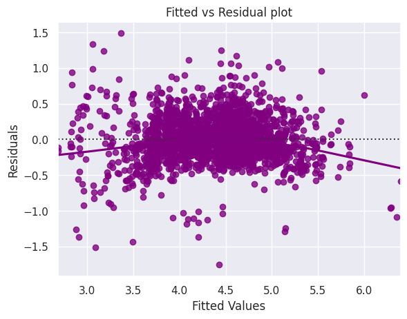

```python
# let's plot the fitted values vs residuals

sns.residplot(
    data=df_pred, x="Fitted Values", y="Residuals", color="purple", lowess=True
)
plt.xlabel("Fitted Values")
plt.ylabel("Residuals")
plt.title("Fitted vs Residual plot")
plt.show()
```

**There is not discernable pattern in the plot above; therefore the assumptions of linearity and independence are satisfied**

### **3.0 Test for Normality**

**Process for determining normality**

The shape of the histogram of residuals can give an initial idea about the normality It can also be checked via a Q-Q plot of residuals If the residuals follow a normal distribution, they will make a straight line plot, otherwise not

**Process for fixing variables if this assumption is not followed**

Apply transformations like log, exponential, arcsinh, etc. as per our data

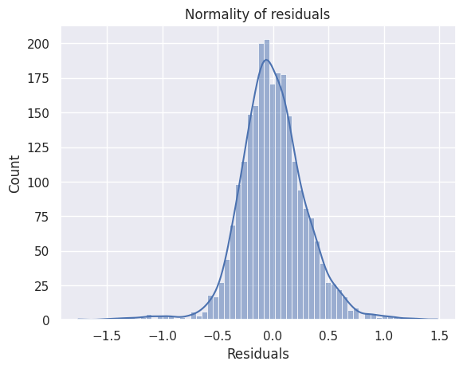

```python
#create a histogram of the residuals
sns.histplot(data=df_pred, x="Residuals", kde=True)
plt.title("Normality of residuals")
plt.show()
```

The histogram of residuals is very close to a bell shape and close enough for the purposes of the test

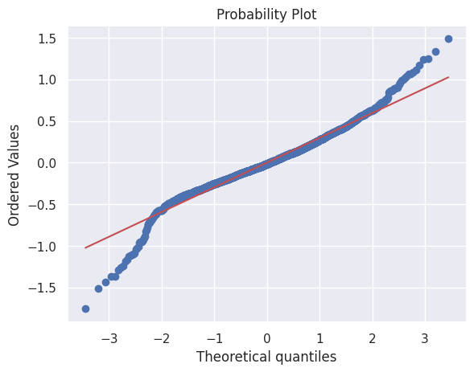

```python
#create a Q-Q plot of residuals
import pylab
import scipy.stats as stats

stats.probplot(df_pred["Residuals"], dist="norm", plot=pylab)
plt.show()
```

Its clear that the residuals follow a straight line until the tails of the Q-Q plot

### **4.0 Test of Heteroscedasticity**

**Process for determining homoscedasticity**

1. The residual vs fitted values plot can be looked at to check for homoscedasticity
2. In the case of heteroscedasticity, the residuals can form an arrow shape or any other non-symmetrical shape
3. The goldfeldquandt test can also be used
4. If we get a p-value > 0.05 we can say that the residuals are homoscedastic

   Null hypothesis: Residuals are homoscedastic

   Alternate hypothesis: Residuals have heteroscedasticity

**Process for fixing variables if this assumption is not followed**

Heteroscedasticity can be fixed by adding other important features or making transformations

```python
import statsmodels.stats.api as sms
from statsmodels.compat import lzip

name = ["F statistic", "p-value"]
test = sms.het_goldfeldquandt(df_pred["Residuals"], x_train2)
lzip(name, test)
```

```
[('F statistic', 1.1425746523674296), ('p-value', 0.010765431019634687)]
```

## Final Model

```python
olsmodel_final = sm.OLS(y_train, x_train1).fit()
print(olsmod2.summary())
```

```
                              OLS Regression Results
=================================================================================
Dep. Variable:     normalized_used_price   R-squared:                       0.747
Model:                               OLS   Adj. R-squared:                  0.746
Method:                    Least Squares   F-statistic:                     709.0
Date:                   Wed, 10 Jul 2024   Prob (F-statistic):               0.00
Time:                           19:06:17   Log-Likelihood:                -515.25
No. Observations:                   2410   AIC:                             1053.
Df Residuals:                       2399   BIC:                             1116.
Df Model:                             10
Covariance Type:               nonrobust
=======================================================================================
                          coef    std err          t      P>|t|      [0.025      0.975]
---------------------------------------------------------------------------------------
const                   2.4880      0.052     47.541      0.000       2.385       2.591
screen_size             0.0396      0.004      9.692      0.000       0.032       0.048
main_camera_mp          0.0398      0.002     23.685      0.000       0.037       0.043
selfie_camera_mp        0.0213      0.001     15.311      0.000       0.019       0.024
int_memory              0.0005   8.28e-05      5.739      0.000       0.000       0.001
ram                     0.0842      0.005     15.860      0.000       0.074       0.095
weight                  0.0012      0.000      7.315      0.000       0.001       0.001
years_since_release     0.0191      0.004      4.421      0.000       0.011       0.028
os_Others              -0.1137      0.037     -3.081      0.002      -0.186      -0.041
os_iOS                  0.2642      0.056      4.699      0.000       0.154       0.374
4g_yes                  0.2046      0.019     11.026      0.000       0.168       0.241
==============================================================================
Omnibus:                      179.044   Durbin-Watson:                   2.040
Prob(Omnibus):                  0.000   Jarque-Bera (JB):              921.116
Skew:                          -0.084   Prob(JB):                    9.60e-201
Kurtosis:                       6.024   Cond. No.                     1.95e+03
==============================================================================

Notes:
[1] Standard Errors assume that the covariance matrix of the errors is correctly specified.
[2] The condition number is large, 1.95e+03. This might indicate that there are
strong multicollinearity or other numerical problems.
```

```python
# checking model performance on train set (seen 70% data)
print("Training Performance\n")
olsmodel_final_train_perf = model_performance_regression(olsmodel_final, x_train1, y_train)
olsmodel_final_train_perf
```

```
Training Performance
```

|  | RMSE | MAE | R-squared | Adj. R-squared | MAPE |
| --- | --- | --- | --- | --- | --- |
| 0 | 0.29965 | 0.221281 | 0.747193 | 0.746033 | 5.343535 |

```python
# checking model performance on test set (seen 30% data)
print("Test Performance\n")
olsmodel_final_test_perf = model_performance_regression(olsmodel_final, x_test1, y_test)
olsmodel_final_test_perf
```

```
Test Performance
```

|  | RMSE | MAE | R-squared | Adj. R-squared | MAPE |
| --- | --- | --- | --- | --- | --- |
| 0 | 0.28481 | 0.208181 | 0.754386 | 0.751742 | 5.035427 |

The model is able to explain ~75% of the variation in the data, which is very good.

The train and test RMSE and MAE are low and comparable. So, the model is not suffering from overfitting.

The Mean Absolute Percentage Error(MAPE) on the test set suggests we can predict the used devices prices within 5.03% error which is good because it is a low value

## Actionable Insights and Recommendations

#### Key take way:

- factors like battery, days_used and 5g_yes do not show significant impact on the price of the refurbished device, hence **Recell** should not worry about those factors a lot. As long as the device is repaired, it will get market.